# Loss Reserve Estimation for Indian MET Lines

Chain Ladder and Bornhuetter-Ferguson Methods

Author

Adi Prakash

Published

June 24, 2026

# 1 Executive Summary

This report presents loss reserve estimates for three non-life insurance lines material to the Indian reinsurance market: Motor (Third Party and Own Damage), Engineering (Industrial All Risk, Construction All Risk, Erection All Risk), and Treaty (proportional and excess-of-loss reinsurance).

Two actuarial reserving methods are applied and compared:

- **Chain Ladder (Mack, 1993)**: A development pattern extrapolation method that projects historical age-to-age factors forward to estimate ultimate losses.
- **Bornhuetter-Ferguson (BF)**: A credibility blend of an a priori expected loss ratio and actual emergence, providing stability for immature and CAT-contaminated accident years.

All triangles in this report are synthetic, generated from parameters calibrated to IRDAI Annual Report 2022-23 and GIC Re Annual Report 2022-23 disclosures.

# 2 Indian Non-Life Market Context

## 2.1 Motor: MACT Judicial Lag

Indian Motor Third Party (TP) claims are adjudicated by Motor Accidents Claims Tribunals (MACT). Judicial delays — arising from case backlogs, appellate proceedings, and structured settlement negotiations — mean that bodily injury claims in India typically develop over 5 to 7 years. This is materially longer than western benchmarks (UK Motor TP typically 70-75% emerged by end of development year 2).

The development pattern used in this analysis reflects this lag:

Motor: Cumulative Development Pattern

| Development Period | % of Ultimate Emerged |
| --- | --- |
| Year 1 | 45% |
| Year 2 | 68% |
| Year 3 | 80% |
| Year 4 | 88% |
| Year 5 | 93% |
| Year 6 | 96% |
| Year 7 | 98% |
| Year 8 | 100% |

Only 45% of ultimate Motor losses are emerged by the end of development year 1, compared to approximately 60-65% in European markets. This has material implications for tail factor selection and IBNR estimation for recent accident years.

## 2.2 Engineering: Catastrophe Contamination

Indian Engineering lines experienced three major catastrophe events in rapid succession:

- **Chennai floods (2015)**: Widespread industrial damage across Tamil Nadu
- **Kerala floods (2018)**: The most severe flooding in Kerala in nearly a century, causing significant IAR and CAR losses
- **Cyclone Fani (2019)**: Category 5 cyclone making landfall in Odisha, with material Engineering losses

These events contaminated accident year development patterns. An insurer or reinsurer applying pure Chain Ladder without adjusting for these years will project CAT-inflated link ratios into future non-CAT years, systematically overstating Engineering reserves.

## 2.3 Treaty: Cedant Aggregation Effect

A treaty reinsurer’s loss triangle aggregates experience across multiple cedants. In years with widespread catastrophe activity — such as 2018 — proportional treaty portfolios absorb CAT losses from cedants simultaneously, elevating the treaty loss ratio in a manner that does not reflect the underlying non-CAT development pattern. GIC Re’s treaty premium approximated INR 8,000-9,000 Crores as of 2022-23 (GIC Re Annual Report 2022-23).

# 3 Data

## 3.1 Triangle Construction

Loss development triangles were constructed synthetically using parameters calibrated to Indian market benchmarks. The simulation methodology follows a lognormal process model:

For each accident year $i$ and development period $j$, cumulative losses $C_{i,j}$ are drawn from:

$$C_{i,j} \sim \text{Lognormal}\left(\mu_{i,j},\ \sigma\right)$$

where $\mu_{i,j} = \log(P_i \times ELR_i \times d_j) - \frac{\sigma^2}{2}$, $P_i$ is earned premium for accident year $i$, $ELR_i$ is the ultimate loss ratio, $d_j$ is the cumulative development pattern at period $j$, and $\sigma$ is set to reflect line-specific process variance.

## 3.2 Parameter Sources

Triangle Simulation Parameters by Line

| Line | Base Premium (AY2016, INR Cr) | Premium Growth | Ultimate ELR Range | Process CV | Primary Source |
| --- | --- | --- | --- | --- | --- |
| Motor | 8,500 | ~12% p.a. | 76-81% | 4% | IRDAI AR 2022-23 |
| Engineering | 420 | ~10% p.a. | 68-95% | 12% | IRDAI AR 2022-23 |
| Treaty | 1,200 | ~10% p.a. | 72-88% | 7% | GIC Re AR 2022-23 |

The Engineering ELR range of 68-95% reflects normal year experience (68-72%) versus CAT-contaminated years (AY2018: 95%, AY2019: 85%), consistent with IRDAI Engineering segment combined ratio data.

## 3.3 Observed Triangles

Motor: Cumulative Incurred Losses (INR Crores)

|  | Dev1 | Dev2 | Dev3 | Dev4 | Dev5 | Dev6 | Dev7 | Dev8 |
| --- | --- | --- | --- | --- | --- | --- | --- | --- |
| AY2016 | 2,905 | 4,546 | 5,093 | 5,805 | 6,158 | 6,580 | 6,570 | 6,510 |
| AY2017 | 3,464 | 5,001 | 6,062 | 6,325 | 7,306 | 6,717 | 7,203 | NA |
| AY2018 | 3,853 | 5,671 | 6,918 | 7,348 | 7,392 | 8,229 | NA | NA |
| AY2019 | 4,308 | 6,260 | 7,021 | 8,436 | 8,180 | NA | NA | NA |
| AY2020 | 4,716 | 6,962 | 8,385 | 9,234 | NA | NA | NA | NA |
| AY2021 | 5,302 | 7,817 | 9,468 | NA | NA | NA | NA | NA |
| AY2022 | 5,344 | 9,201 | NA | NA | NA | NA | NA | NA |
| AY2023 | 6,398 | NA | NA | NA | NA | NA | NA | NA |

Engineering: Cumulative Incurred Losses (INR Crores)

|  | Dev1 | Dev2 | Dev3 | Dev4 | Dev5 | Dev6 | Dev7 | Dev8 |
| --- | --- | --- | --- | --- | --- | --- | --- | --- |
| AY2016 | 136.2 | 209.8 | 245.1 | 243.4 | 270.3 | 234.2 | 255.8 | 225 |
| AY2017 | 182.5 | 263.7 | 283.0 | 349.7 | 282.6 | 309.3 | 386.4 | NA |
| AY2018 | 256.5 | 475.1 | 404.8 | 512.4 | 554.6 | 491.0 | NA | NA |
| AY2019 | 286.2 | 407.0 | 461.1 | 464.5 | 468.3 | NA | NA | NA |
| AY2020 | 252.8 | 351.7 | 356.7 | 565.9 | NA | NA | NA | NA |
| AY2021 | 306.9 | 394.5 | 370.1 | NA | NA | NA | NA | NA |
| AY2022 | 232.5 | 374.0 | NA | NA | NA | NA | NA | NA |
| AY2023 | 323.3 | NA | NA | NA | NA | NA | NA | NA |

Treaty: Cumulative Incurred Losses (INR Crores)

|  | Dev1 | Dev2 | Dev3 | Dev4 | Dev5 | Dev6 | Dev7 | Dev8 |
| --- | --- | --- | --- | --- | --- | --- | --- | --- |
| AY2016 | 416 | 633 | 753 | 797 | 795 | 926 | 781 | 819 |
| AY2017 | 473 | 722 | 878 | 945 | 986 | 1,000 | 904 | NA |
| AY2018 | 594 | 967 | 1,045 | 1,135 | 1,270 | 1,298 | NA | NA |
| AY2019 | 653 | 856 | 1,032 | 1,237 | 1,235 | NA | NA | NA |
| AY2020 | 639 | 863 | 1,294 | 1,249 | NA | NA | NA | NA |
| AY2021 | 673 | 952 | 1,199 | NA | NA | NA | NA | NA |
| AY2022 | 820 | 1,106 | NA | NA | NA | NA | NA | NA |
| AY2023 | 799 | NA | NA | NA | NA | NA | NA | NA |

# 4 Methodology

## 4.1 Chain Ladder

The Chain Ladder method estimates age-to-age development factors using volume-weighted averages across accident years:

$$f_j = \frac{\sum_{i=1}^{n-j} C_{i,j+1}}{\sum_{i=1}^{n-j} C_{i,j}}$$

The cumulative development factor (CDF) from period $j$ to ultimate is the product of all subsequent link ratios:

$$F_j = f_j \times f_{j+1} \times \cdots \times f_{n-1}$$

The projected ultimate for accident year $i$ with latest observed development at period $j^*$ is:

$$\hat{U}_i = C_{i,j^*} \times F_{j^*}$$

IBNR is then:

$$\widehat{IBNR}_i = \hat{U}_i - C_{i,j^*}$$

### 4.1.1 Mack Standard Error

Mack (1993) provides a distribution-free estimate of the reserve standard error, decomposing total uncertainty into process variance and parameter variance. The Mack standard error provides a measure of reserve uncertainty without requiring an assumed claims distribution — a key advantage over parametric alternatives.

## 4.2 Bornhuetter-Ferguson

The BF method estimates IBNR as:

$$\widehat{IBNR}_{BF,i} = \mu_i \times \left(1 - \frac{1}{F_{j^*}}\right)$$

where $\mu_i = P_i \times ELR^{AP}$ is the a priori ultimate (premium multiplied by the expected loss ratio), and $\left(1 - \frac{1}{F_{j^*}}\right)$ is the proportion of ultimate losses not yet emerged at the latest observed period.

The BF ultimate is:

$$\hat{U}_{BF,i} = C_{i,j^*} + \widehat{IBNR}_{BF,i}$$

### 4.2.1 A Priori ELR Selection

A Priori ELR Selection and Sources

| Line | A Priori ELR | Rationale |
| --- | --- | --- |
| Motor | 77% | IRDAI AR 2022-23: industry net incurred loss ratio for Motor ~76-78% |
| Engineering | 70% | IRDAI Eng segment normalised for CAT years; non-CAT ELR ~68-72% |
| Treaty | 73% | GIC Re AR 2022-23: net combined ratio ~98%, expense ratio ~25% |

For Engineering, the a priori ELR of 70% deliberately excludes CAT year experience. This is the central purpose of BF in this context: providing a stable prior that is not contaminated by event-driven anomalies in the triangle.

## 4.3 Method Selection Framework

The preferred reserving method for each accident year is determined by the following rules, applied in order:

1. **CAT-contaminated AY** (Engineering AY2018, AY2019): BF preferred regardless of maturity. CL link ratios are distorted upward.
2. **Immature AY** (< 60% emerged): BF preferred. Insufficient emergence for CL to be credible.
3. **Mature AY** (≥ 90% emerged): CL preferred. Sufficient data.
4. **Intermediate AY** (60-90% emerged): Credibility blend — $w \times IBNR_{BF} + (1-w) \times IBNR_{CL}$ where $w = (1 - \%\ emerged)$.

# 5 Results

## 5.1 Development Factor Diagnostics

Before examining reserve estimates, it is important to assess whether the Chain Ladder assumption of stable development factors holds. The following charts show individual accident year link ratios against the volume-weighted average used by CL.

[figure not shown]

## 5.2 Chain Ladder Results

Chain Ladder Results by Line and Accident Year (INR Crores)

| Line | AY | Premium | Latest Obs | CL Ultimate | CL IBNR | Ult LR% |
| --- | --- | --- | --- | --- | --- | --- |
| **Motor** |  |  |  |  |  |  |
| Motor | AY2016 | 8,500 | 6,510.4 | 6,510.4 | 0.0 | 76.6 |
| Motor | AY2017 | 9,520 | 7,202.8 | 7,137.9 | -64.9 | 75.0 |
| Motor | AY2018 | 10,660 | 8,228.5 | 8,445.9 | 217.4 | 79.2 |
| Motor | AY2019 | 11,940 | 8,179.8 | 8,665.5 | 485.6 | 72.6 |
| Motor | AY2020 | 13,370 | 9,234.4 | 10,175.7 | 941.3 | 76.1 |
| Motor | AY2021 | 14,970 | 9,468.5 | 11,577.3 | 2,108.9 | 77.3 |
| Motor | AY2022 | 16,770 | 9,201.3 | 13,326.6 | 4,125.4 | 79.5 |
| Motor | AY2023 | 18,780 | 6,398.5 | 14,093.4 | 7,694.9 | 75.0 |
| **Engineering** |  |  |  |  |  |  |
| Engineering | AY2016 | 420 | 225.0 | 225.0 | 0.0 | 53.6 |
| Engineering | AY2017 | 460 | 386.4 | 339.9 | -46.5 | 73.9 |
| Engineering | AY2018 | 510 | 491.0 | 510.3 | 19.4 | 100.1 |
| Engineering | AY2019 | 555 | 468.3 | 454.6 | -13.6 | 81.9 |
| Engineering | AY2020 | 600 | 565.9 | 551.4 | -14.5 | 91.9 |
| Engineering | AY2021 | 650 | 370.1 | 440.0 | 69.9 | 67.7 |
| Engineering | AY2022 | 710 | 374.0 | 448.6 | 74.6 | 63.2 |
| Engineering | AY2023 | 775 | 323.3 | 580.6 | 257.3 | 74.9 |
| **Treaty** |  |  |  |  |  |  |
| Treaty | AY2016 | 1,200 | 819.2 | 819.2 | 0.0 | 68.3 |
| Treaty | AY2017 | 1,320 | 904.4 | 948.3 | 43.9 | 71.8 |
| Treaty | AY2018 | 1,450 | 1,297.6 | 1,191.1 | -106.5 | 82.1 |
| Treaty | AY2019 | 1,595 | 1,234.6 | 1,197.3 | -37.3 | 75.1 |
| Treaty | AY2020 | 1,755 | 1,249.0 | 1,262.2 | 13.1 | 71.9 |
| Treaty | AY2021 | 1,930 | 1,198.5 | 1,298.4 | 99.8 | 67.3 |
| Treaty | AY2022 | 2,120 | 1,106.4 | 1,488.2 | 381.8 | 70.2 |
| Treaty | AY2023 | 2,335 | 798.8 | 1,535.8 | 737.0 | 65.8 |

## 5.3 BF vs Chain Ladder Comparison

BF vs Chain Ladder IBNR Comparison (INR Crores)

| Line | AY | BF IBNR | CL IBNR | Difference | Diff % |
| --- | --- | --- | --- | --- | --- |
| **Motor** |  |  |  |  |  |
| Motor | AY2016 | 0.0 | 0.0 | 0.0 | NaN |
| Motor | AY2017 | -66.6 | -64.9 | -1.7 | 2.7 |
| Motor | AY2018 | 211.2 | 217.4 | -6.2 | -2.8 |
| Motor | AY2019 | 515.3 | 485.6 | 29.7 | 6.1 |
| Motor | AY2020 | 952.3 | 941.3 | 11.0 | 1.2 |
| Motor | AY2021 | 2099.7 | 2108.9 | -9.2 | -0.4 |
| Motor | AY2022 | 3997.3 | 4125.4 | -128.1 | -3.1 |
| Motor | AY2023 | 7895.4 | 7694.9 | 200.5 | 2.6 |
| **Engineering** |  |  |  |  |  |
| Engineering | AY2016 | 0.0 | 0.0 | 0.0 | NaN |
| Engineering | AY2017 | -44.1 | -46.5 | 2.4 | -5.2 |
| Engineering | AY2018 | 13.5 | 19.4 | -5.9 | -30.3 |
| Engineering | AY2019 | -11.7 | -13.6 | 1.9 | -14.3 |
| Engineering | AY2020 | -11.0 | -14.5 | 3.5 | -24.0 |
| Engineering | AY2021 | 72.3 | 69.9 | 2.4 | 3.5 |
| Engineering | AY2022 | 82.7 | 74.6 | 8.1 | 10.8 |
| Engineering | AY2023 | 240.4 | 257.3 | -16.9 | -6.6 |
| **Treaty** |  |  |  |  |  |
| Treaty | AY2016 | 0.0 | 0.0 | 0.0 | NaN |
| Treaty | AY2017 | 44.6 | 43.9 | 0.7 | 1.6 |
| Treaty | AY2018 | -94.7 | -106.5 | 11.8 | -11.1 |
| Treaty | AY2019 | -36.3 | -37.3 | 1.0 | -2.8 |
| Treaty | AY2020 | 13.3 | 13.1 | 0.2 | 1.4 |
| Treaty | AY2021 | 108.3 | 99.8 | 8.5 | 8.5 |
| Treaty | AY2022 | 397.1 | 381.8 | 15.3 | 4.0 |
| Treaty | AY2023 | 818.0 | 737.0 | 81.0 | 11.0 |

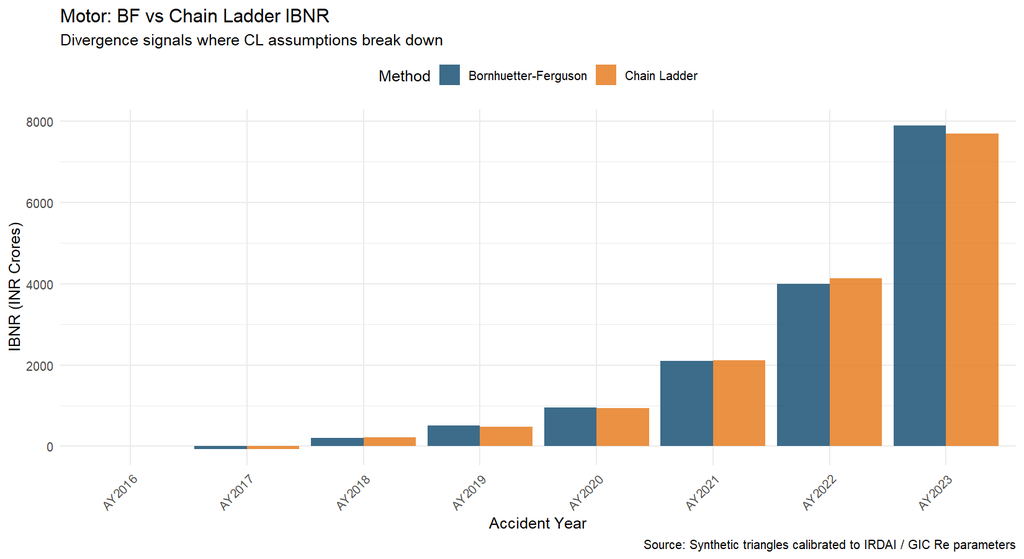

Motor: BF vs Chain Ladder IBNR. Methods converge — high volume yields stable link ratios, giving CL high credibility.

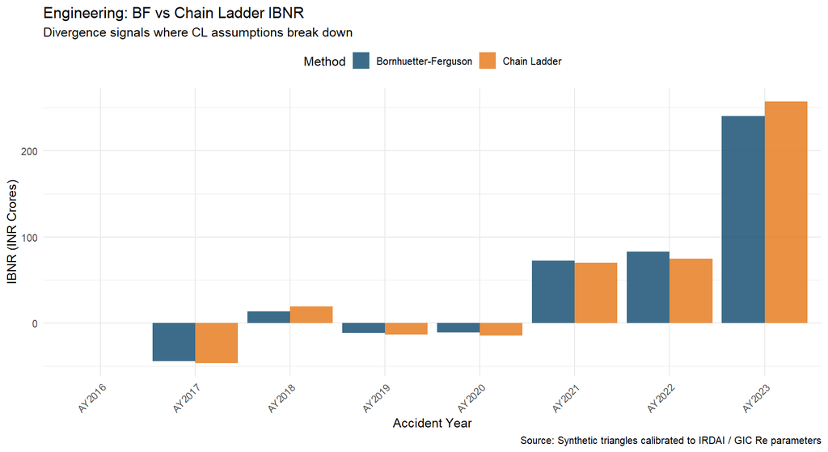

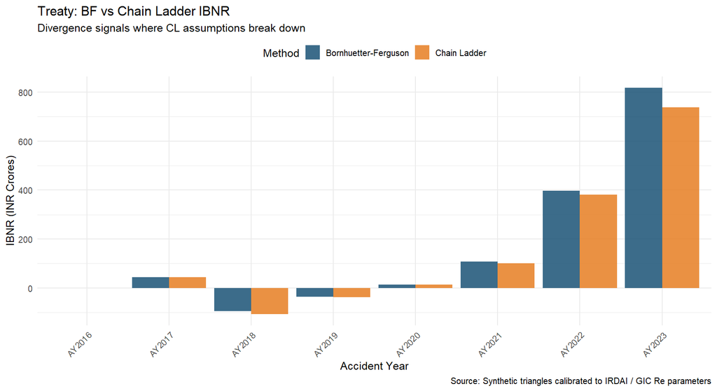

Treaty: BF vs Chain Ladder IBNR. BF produces higher estimates for immature AYs, reflecting greater reliance on the a priori ELR.

## 5.4 Portfolio Summary

Portfolio Summary: Total IBNR by Line (INR Crores)

| Line | Total Premium | Total Latest Obs | Total IBNR (CL) | Total IBNR (BF) | CL vs BF (%) |
| --- | --- | --- | --- | --- | --- |
| Engineering | 4,680 | 3,204 | 347 | 342 | 1.3 |
| Motor | 104,510 | 64,424 | 15,509 | 15,605 | -0.6 |
| Treaty | 13,705 | 8,608 | 1,132 | 1,250 | -9.5 |

# 6 Key Findings and Actuarial Commentary

## 6.1 Finding 1: Motor — Methods Converge

CL and BF produce closely aligned IBNR estimates for Motor across all accident years. The high volume of Motor business yields stable, credible development factors. The minor divergence observed in AY2022 and AY2023 reflects BF giving more weight to the a priori in immature years — appropriate given limited emergence at those dates.

The Motor development pattern is materially slower than western benchmarks, consistent with MACT judicial delays. A practitioner applying western Motor TP development factors to an Indian book would understate the tail and underestimate IBNR for recent accident years.

## 6.2 Finding 2: Engineering — CAT Contamination Requires BF

This is the central actuarial finding of this report. The Kerala floods (2018) and Cyclone Fani (2019) generated elevated loss development in their respective accident years. CL incorporates these inflated link ratios into the volume-weighted average, which is then applied to all accident years — including future years where no comparable CAT is assumed.

## 6.3 Finding 3: Treaty — Immature Year Stability

# 7 Limitations and Extensions

## 7.1 Limitations of This Analysis

**Synthetic data**: All triangles are generated from calibrated parameters rather than actual insurer or reinsurer data. Results should be interpreted as illustrative of methodology, not as estimates of any specific entity’s reserves.

**Tail factor**: A tail factor of 1.000 is assumed for all lines, implying all development is complete by period 8. For Motor TP in India, given MACT delays, a tail factor greater than 1.0 may be warranted and should be investigated with actual data.

**No calendar year effects**: The Mack model assumes accident years are independent. In practice, Indian Motor TP reserves may be affected by calendar year effects (e.g., changes in MACT award levels, inflation in court settlements). A diagonal effects test (Thomas, 2006) would be appropriate for production use.

**CAT year exclusion**: This analysis flags AY2018 and AY2019 as CAT-contaminated and uses BF. In practice, an actuary would also consider excluding these years from the link ratio calculation entirely, or applying a weighted average that downweights event years.

## 7.2 Suggested Extensions

- **Generalised Linear Model (GLM) reserving** via `glmReserve()` in ChainLadder — provides a parametric alternative with explicit distributional assumptions
- **Munich Chain Ladder** — uses both paid and incurred triangles simultaneously, appropriate where both are available
- **CAT-adjusted link ratios** — explicitly exclude or downweight AY2018/2019 from the Engineering link ratio calculation and compare results
- **Tail factor estimation** — fit a curve (e.g., inverse power, exponential) to the development pattern to extrapolate beyond period 8 for Motor TP

# 8 References

- Mack, T. (1993). Distribution-Free Calculation of the Standard Error of Chain Ladder Reserve Estimates. *ASTIN Bulletin*, 23(2), 213-225.
- Bornhuetter, R.L. and Ferguson, R.E. (1972). The Actuary and IBNR. *Proceedings of the Casualty Actuarial Society*, 59, 181-195.
- IRDAI (2023). *Annual Report 2022-23*. Insurance Regulatory and Development Authority of India.
- IRDAI (2023). *Handbook of Indian Insurance Statistics 2022-23*.
- GIC Re (2023). *Annual Report 2022-23*. General Insurance Corporation of India.
- Gesmann, M. et al. (2024). *ChainLadder: Statistical Methods and Models for Claims Reserving in General Insurance*. R package version 0.2.21.

*This report was produced using R (version 4.6.0) and Quarto. All analysis is reproducible from the accompanying GitHub repository.*

*Methodology questions or feedback welcome via LinkedIn.*